# L2G enrichment for Mendelian Disease

Jeremy Schwartzentruber

09/12/2020

We ran MendelVar (https://mendelvar.mrcieu.ac.uk/) using lead SNPs (top loci from Open Targets Genetics) for 9 traits. We loaded the disease_overlap.txt file for each result, which has the Mendelian disease genes that overlap within a window around each SNP. I used a window of 100 kb. Each locus may therefore have more than one gene overlap, and some of these may have a matching phenotype, based on HPO, while others may not.

I manually selected a number of HPO terms specific to each GWAS trait by searching EBI’s ontology lookup (https://www.ebi.ac.uk/ols/search), and recorded these in a file studies_hpo.tsv. (Also online: https://docs.google.com/spreadsheets/d/1ibTIMnGqeMF4zoPjTEEamUZ4V533ChhmAP6GYdYkG_M/edit#gid=0). Using this, I determine whether each overlapping Mendelian disease gene has a phenotype matching the GWAS trait. I then annotate the locus2gene score for each GWAS study/gene combination.

## L2G distribution

Here, I plot the distribution of L2G scores for genes with a matching Mendelian disease, genes with a non-matching Mendelian disease, and all other L2G genes.

One confounding factor is that L2G scores include all genes within 500 kb, whereas for MendelVar I used a window of 100 kb, expecting that this would give a better enrichment.

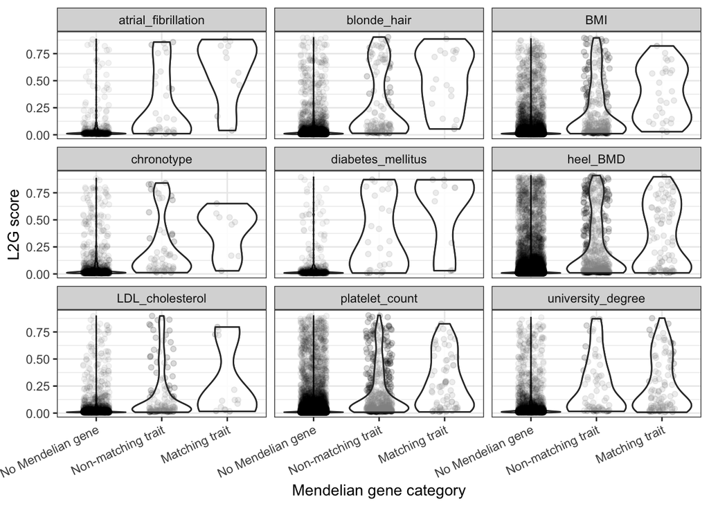

Let’s also plot it without the “No Mendelian gene” case.

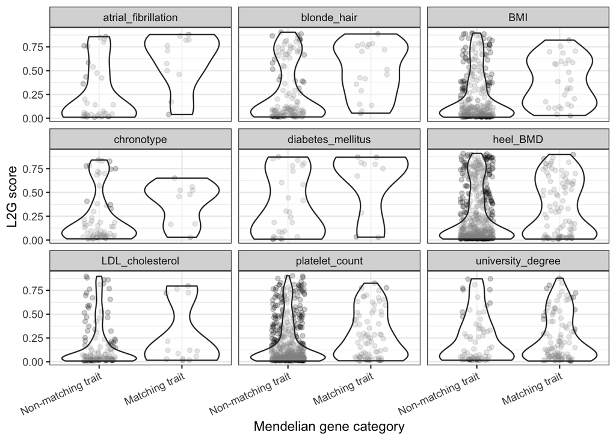

## Enrichments

Here we look at the enrichment of genes with L2G score > 0.5 for matching traits vs. non-matching (Fisher’s exact test).

| study_id | trait | OR | OR_conf_lo | OR_conf_hi | p_value |
| --- | --- | --- | --- | --- | --- |
| GCST006612 | LDL_cholesterol | 2.271689 | 0.4690552 | 9.024633 | 0.2442524 |
| GCST006979 | heel_BMD | 2.026327 | 1.2069052 | 3.368973 | 0.0048607 |
| NEALE2_1180 | chronotype | 3.134165 | 0.5372097 | 17.215035 | 0.1965263 |
| NEALE2_1747_1 | blonde_hair | 2.354929 | 0.7578672 | 7.338789 | 0.1064048 |
| NEALE2_21001_raw | BMI | 2.691152 | 1.0698904 | 6.531696 | 0.0256219 |
| NEALE2_30080_raw | platelet_count | 1.889954 | 0.9834495 | 3.505533 | 0.0394875 |
| NEALE2_6138_1 | university_degree | 1.237269 | 0.5459453 | 2.905290 | 0.7023627 |
| SAIGE_250 | diabetes_mellitus | 4.216763 | 0.7387534 | 31.620304 | 0.0731581 |
| SAIGE_427_2 | atrial_fibrillation | 8.168404 | 1.5188674 | 59.577012 | 0.0085222 |